# Medidas de Posición

Estadística Descriptiva

10/27/2020

Las **medidas de posición** se utilizan para describir la posición que un dato específico posee en relación con el resto de los datos cuando están en orden por categorías. *Cuartiles* y *percentiles* son dos de las medidas de posición más populares.

# Cuartiles

Son valores de la variable que dividen los datos ordenados en cuartos;cada conjunto de datos tiene tres cuartiles.

- El *primer cuartil*, $Q_1$, es un número tal que a lo sumo 25% de datos son menores en valor que $Q_1$ y a lo sumo 75% son mayores.
- El *segundo cuartil* es la mediana.
- El *tercer cuartil*, $Q_3$, es un número tal que a lo sumo 75% de los datos son menores en valor que $Q_3$ y a lo sumo 25% son mayores.

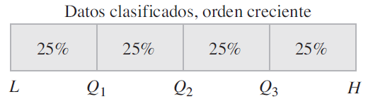

Donde $L$ es el valor más bajo de los datos que tenemos, y $H$ y es el valor más alto de todos los que tenemos.

# Percentiles

Son los valores de la variable que dividen un conjunto de datos clasificados en 100 subconjuntos iguales; cada conjunto de datos tiene 99 percentiles. El $k$-ésimo percentil, $P_k$, es un valor tal que a lo sumo $k$% de los datos son menores en valor que $P_k$ y a lo sumo $(100 – k)$% de los datos son mayores.

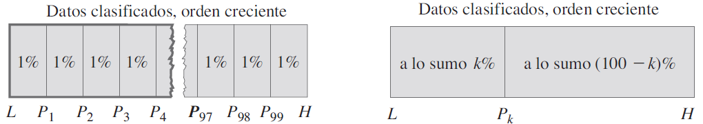

**Notas:**

1. El primer cuartil y el 25avo percentil son lo mismo; es decir $Q_1 = P_{25}$. También tenemos que $Q_3 = P_{75}$.
2. La mediana, el segundo cuartil y el 50avo percentil son todos lo mismo: $\tilde{x} = Q_2 = P_{50}$. Por tanto, cuando se nos pida hallar $P_{50}$ o $Q_2$, usamos el procedimiento para hallar la mediana.

## Obtención de los cuartiles

- **Paso 1.** Ordenar los datos de menor a mayor
- **Paso 2.** El primer cuartil ($Q_1$) de todas las observaciones es la mediana del conjunto de datos que está por debajo de la mediana.
- **Paso 3.** El tercer cuartil ($Q_3$) de todas las observaciones es la mediana del conjunto de datos que está por arriba de la mediana.

### Ejemplo

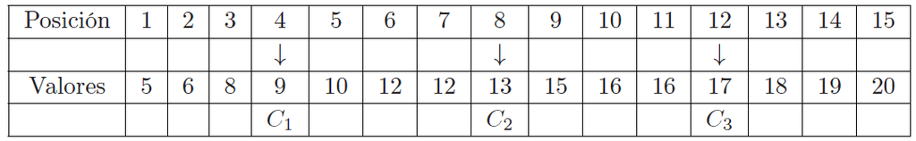

## Obtención de los percentiles

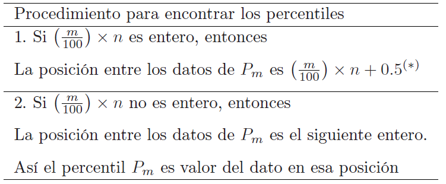

### Ejemplo

Las compañías de seguros les piden a sus posibles clientes que se realicen pruebas para verificar su estado de salud. Esta acción va en el sentido de que éstas no tengan pérdidas económicas. Un Colegio de primaria realiza un estudio médico a una muestra de 62 profesores. Entre los resultados del estudio se encuentran la variable $X$ que son los niveles de colesterol, que tiene los valores:

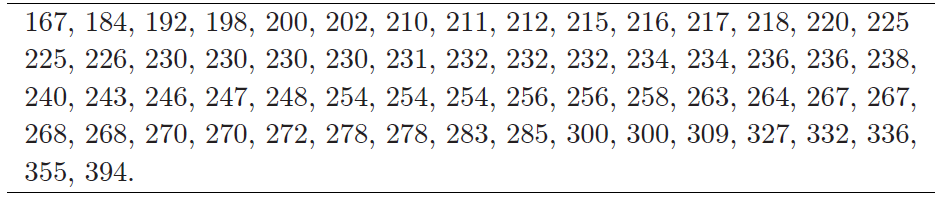

1. Encontrar el percentil 50, o sea, $P_{50}$. En la fórmula anterior reemplazamos $m = 50$ y $n = 62$, y obtenemos

$$\left(\frac{m}{100}\right) \times n = \left(\frac{50}{100}\right) \times 62 = 31$$
La posición es $31 + 0.5$, entonces el valor es la media entre los valores que están en la posición $31$ y $32$. Éstos corresponden a $240$ y $243$, de esa manera la media de esos datos es el valor $241.5$. Observe que este último valor corresponde a la mediana.

2. Encontrar el percentil 80, o sea, $P_{80}$. En este caso tenemos $m = 80$ y $n=62$:

$$\left(\frac{m}{100}\right) \times n = \left(\frac{80}{100}\right) \times 62 = 49.6$$
Así, la posición corresponde al dato en el lugar $50$, entonces el percentil $P_{80} = 272$.

## Rango percentil

Es de utilidad dado un valor del conjunto de datos, saber a qué percentil pertenece. Se puede decir que el rango percentil es el proceso inverso, ahora se da un nivel del colesterol y hay que determinar cuál es el percentil. Se obtiene a partir de la siguiente regla:

El rango percentil $m$ de un dato $x$ es:

$$m = \left(\frac{\textrm{Número de datos menores que } x}{\textrm{Número total de datos}}\right) \times 100$$

Hay que destacar que los resultados son aproximados.

**Ejemplo:**

A partir de los datos de las medidas de colesterol de los profesores, encontrar el rango percentil para el dato 226.

Observe que hay 16 datos antes del 226 en la lsita de 62 observaciones. El cálculo es:

$$m = \left(\frac{16}{62}\right) \times 100 = 25.8 \approx 26$$

Entonces 226 es el percentil 26 o $P_{26}$, muy cercano al primer cuartil.

## Cuartil medio

El valor numérico que está al centro entre el primer cuartil y el tercer cuartil. Se halla de acuerdo a la siguiente fórmula:

$$\textrm{cuartil medio} = \frac{Q_1 + Q_3}{2}$$

## Rango intercuartil

Es la diferencia entre los cuartiles primero y tercero. Es el rango del 50% central de los datos.

# La media armónica y la media geométrica

La *media armónica* y la *media geométrica* completan el panorama de medidas de tendencia central. En la práctica, éstas suelen usarse menos y en general para aplicaciones específicas, por ejemplo en comercio y economía.

## La media armónica

La *media armónica* (que se denota con la letra $H$) de un conjunto de datos $x_1, x_2, \cdots , x_n$ es el recíproco de la media aritmética del recíproco de esos datos:

$$H = \frac{1}{\frac{1}{n}\sum_{i=1}^{n}\frac{1}{x_i}} = \frac{n}{\sum_{i=1}^{n}\frac{1}{x_i}}$$
La media armónica se emplea cuando se desea promediar velocidades, tiempos, rendimiento, etc., es decir, cuando influyen los valores pequeños. Pero es necesario ser cuidadoso en estos casos, ya que cuando algún dato es cero o muy cercano a cero, no se puede calcular.

**Ejemplo:**

La administración de una empresa está interesada en conocer la producción por hora de las cinco máquinas que tiene operando, las cuales se usan para producir un componente para el asiento de un automóvil. Cada una de las cinco máquinas lo hace en 3.5, 2.9, 1.5, 5.5 y 4 minutos. ¿Cuál es la velocidad promedio calculada a través de la media armónica?

**Solución:**

## La media geométrica

Si algunos valores son muy grandes en magnitud y otros son pequeños, entonces la media geométrica es una medida que representa los datos mejor que la media.

Si hay $n$ observaciones $x_1, x_2, \cdots , x_n$, la media geométrica $G$ de un conjunto de datos es la raíz enésima del producto de esos datos.

$$G = \sqrt[n]{x_1 \times x_2 \times \cdots \times x_n}$$
Por lo general, la media geométrica se utiliza cuando los valores de la variable siguen una progresión geométrica, o cuando se necesitan promediar porcentajes, tasas, índices, etc., siempre que vengan dados en porcentajes.

**Ejemplo**

Los registros estadísticos de la Secretaria de Salud señalan que el número de personas que se enferman a causa de su hábito de fumar aumenta año con año. El hábito de fumar tiene repercusiones económicas en el sector salud.

El registro de un hospital indica que el número de personas de 25 años que se enferma a causa de su hábito de fumar aumenta año con año. ¿Cuál es el porcentaje promedio de incremento en la cantidad de enfermos que ocurren por año? Los datos de la secreatría indican que el incremento del año 2013 a 2014 fue del 240%, del 2014 al 2015 el incremento fue del 133%, del 2015 al 2016 el incremento fue del 156%, del 2016 al 2017 el incremento llego al 160% y del 2017 al 2018, el incremento fue del 163%.

**Solución**

Aplicando la fórmula para el promedio geométrico tenemos:

$$G = \sqrt[n]{x_1x_2\cdots\,x_n} = \sqrt[5]{2.4 \times 1.33 \times 1.56 \times 1.60 \times 1.63} = 1.669$$

es decir, un aumento medio por año de 66.9%. Este resultado indica que en los últimos cinco años en promedio, el número de enfermos por el hábito de fumar ha crecido. Con esta información las autoridades encargadas de la salud deben aplicar planes para remediar esta situación.

# ¿Como hacemos esto en R?

Todas estas medidas también la podemos hacer en R. Suponga que vamos a trabajar con el ejercicio del colesterol en los profesores. Para ello vamos a crear un objeto denominado `colesterol` con la información proporcionada.

```r
colesterol <- c(167, 184, 192, 198, 200, 202, 210, 211, 212, 215, 216, 217, 218, 220, 225,
                225, 226, 230, 230, 230, 230, 231, 232, 232, 232, 234, 234, 236, 236, 238,
                240, 243, 246, 247, 248, 254, 254, 254, 256, 256, 258, 263, 264, 267, 267,
                268, 268, 270, 270, 272, 278, 278, 283, 285, 300, 300, 309, 327, 332, 336,
                355, 394)
```

## Medidas de tendencia central

```r
library(modeest)

# Media
mean(colesterol)
```

```
## [1] 250.0806
```

```r
# Mediana
median(colesterol)
```

```
## [1] 241.5
```

```r
# Moda
mfv(colesterol)
```

```
## [1] 230
```

## Cuartiles

```r
# Ver los cuartiles de la variable "colesterol"
quantile(colesterol)
```

```
##     0%    25%    50%    75%   100%
## 167.00 225.25 241.50 268.00 394.00
```

## Percentiles

```r
# Ver los percentiles 35, 60 y 96 de la variable colesterol
quantile(colesterol, c(0.35, 0.60, 0.96))
```

```
##    35%    60%    96%
## 231.35 254.00 334.24
```

## Media armónica

```r
# Guardamos en n el tamaño de la variable "colesterol"
n <- length(colesterol)

# Y ahora obtenemos la media armónica
1 / mean(1/colesterol)
```

```
## [1] 243.9449
```

## Media geométrica

```r
n <- length(colesterol)

# Aquí sacamos la raíz enésima de los datos del colesterol
prod(colesterol) ^ (1/n)
```

```
## [1] 246.9207
```

## Rango percentil

Si queremos saber el rango percentil del número $300$.

```r
# Primero obtenemos el tamaño de los datos
n <- length(colesterol)

# Ahora obetenemos cuántos son menores al número que nos interesa
m <- 300
menores_a_m <- length(colesterol[colesterol < m])

# Y ahora hallamos el rango percentil para el número
rango_percentil <- round(menores_a_m / n * 100)
cat("El rango percentil es", rango_percentil)
```

```
## El rango percentil es 87
```